# Remote Work & Mental Health Project

# Distribution of Categorical Variables, check data imbalance

Visualize the distribution of categorical variables such as Work_Location, Gender, Stress_Level, etc.

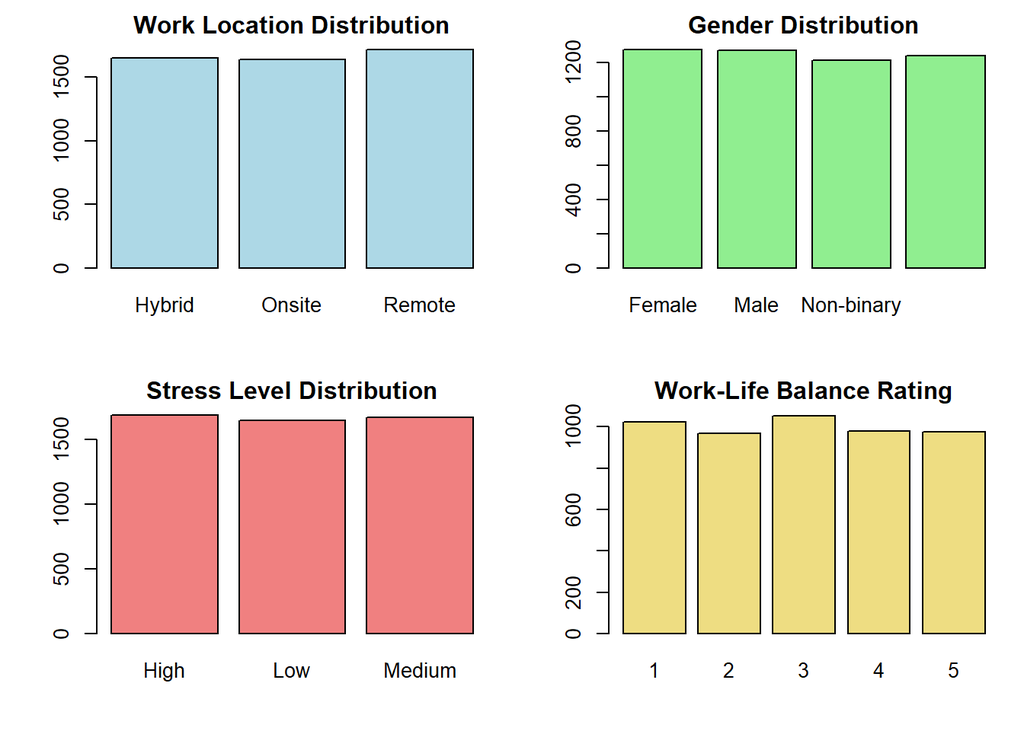

```r
# Set up plotting layout for multiple smaller plots in a single window
par(mfrow = c(2, 2)) # 2 rows and 2 columns of plots
par(mar = c(4, 4, 2, 1))

# Visualize Work_Location
barplot(table(Remote$Work_Location),
        main = "Work Location Distribution",
        col = "lightblue",
        ylim = c(0, max(table(Remote$Work_Location)) + 10))

# Visualize Gender
barplot(table(Remote$Gender),
        main = "Gender Distribution",
        col = "lightgreen",
        ylim = c(0, max(table(Remote$Gender)) + 10))

# Visualize Stress_Level
barplot(table(Remote$Stress_Level),
        main = "Stress Level Distribution",
        col = "lightcoral",
        ylim = c(0, max(table(Remote$Stress_Level)) + 10))

# Visualize Work_Life_Balance_Rating
barplot(table(Remote$Work_Life_Balance_Rating),
        main = "Work-Life Balance Rating",
        col = "lightgoldenrod",
        ylim = c(0, max(table(Remote$Work_Life_Balance_Rating)) + 10))
```

```r
# Reset plotting layout to default
par(mfrow = c(1, 1))
```

> Comment: Employees are almost evenly distributed across the three work locations: Hybrid, Onsite, and Remote. No significant skew or concentration in any one category. There was a balanced gender distribution in the dataset. Employees report an almost equal distribution of stress levels across High, Medium, and Low categories. Ratings from 1 to 5 are almost evenly distributed, no strong bias toward a particular rating.

## Exploratory Data Analysis (EDA)

# Plotting the Age Distribution

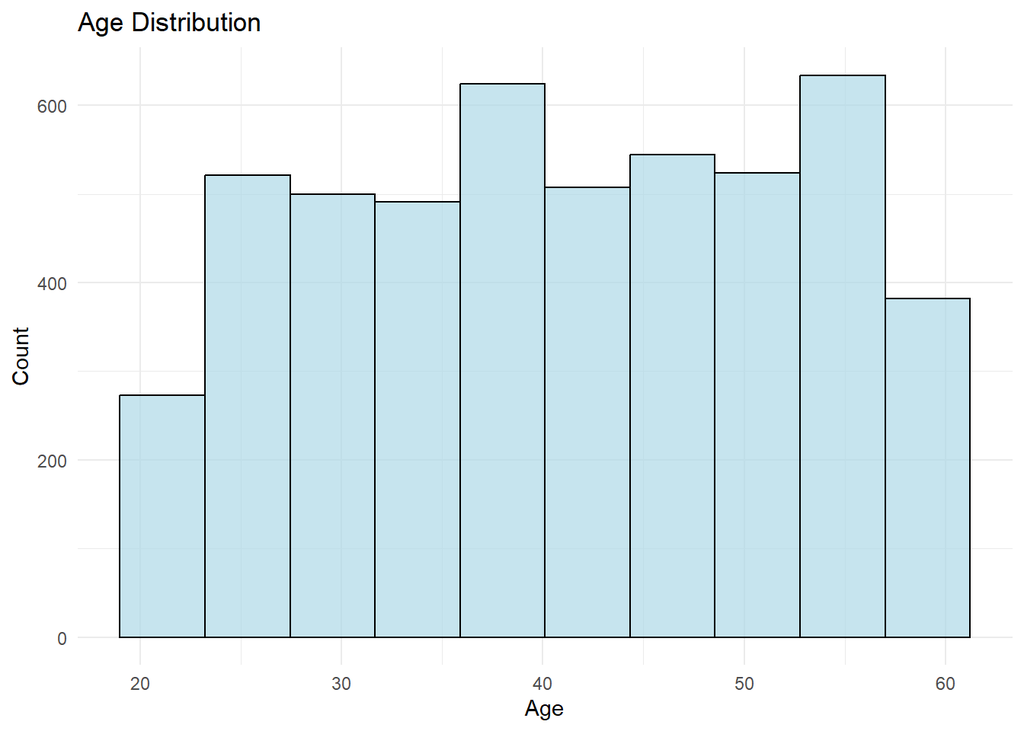

```r
ggplot(Remote, aes(x = Age)) +
  geom_histogram(bins = 10, fill = "lightblue", color = "black", alpha = 0.7) +
  labs(title = "Age Distribution", x = "Age", y = "Count") +
  theme_minimal()
```

# Plotting the Job Role, and Industry Distribution

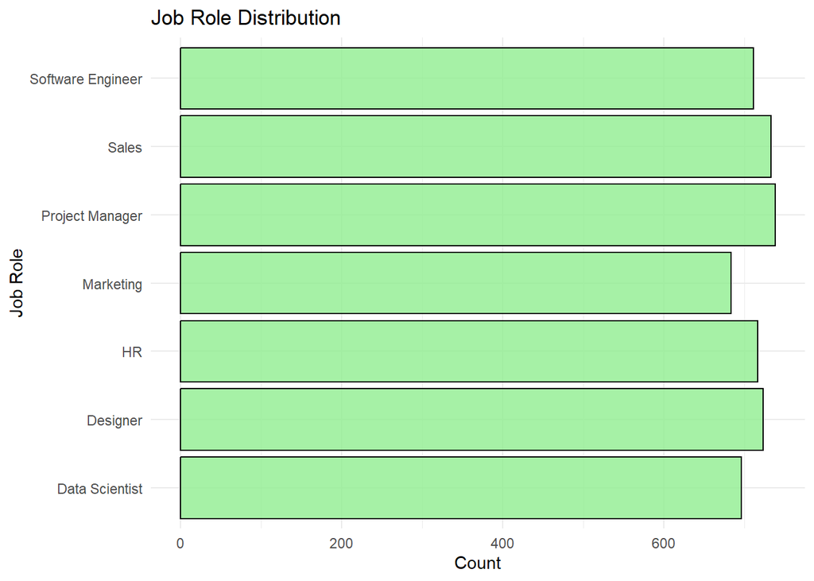

```r
ggplot(Remote, aes(x = Job_Role)) +
  geom_bar(fill = "lightgreen", color = "black", alpha = 0.8) +
  coord_flip() +
  labs(title = "Job Role Distribution", x = "Job Role", y = "Count") +
  theme_minimal()
```

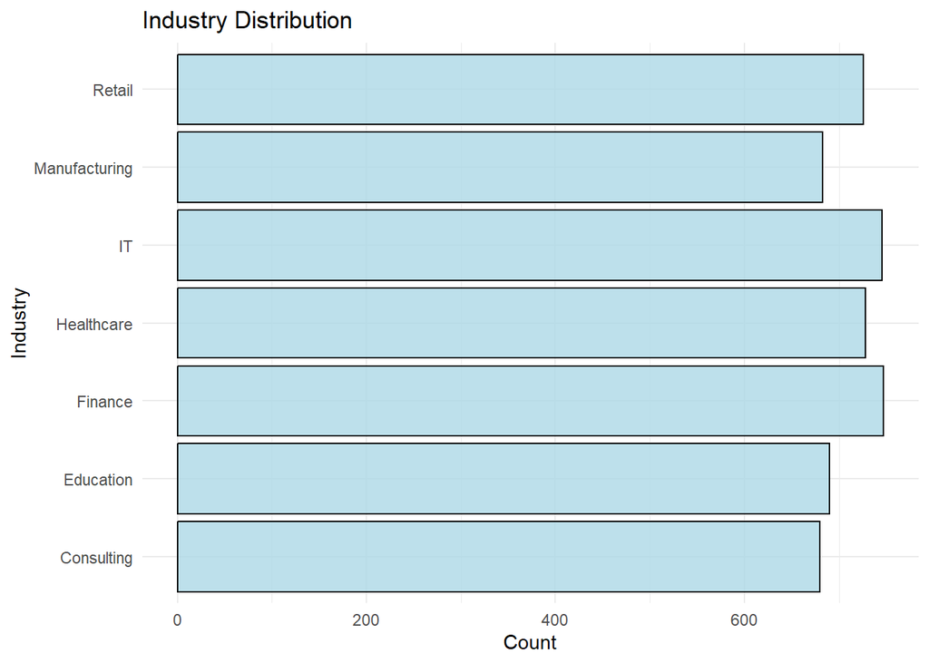

```r
ggplot(Remote, aes(x = Industry)) +
  geom_bar(fill = "lightblue", color = "black", alpha = 0.8) +
  coord_flip() +
  labs(title = "Industry Distribution", x = "Industry", y = "Count") +
  theme_minimal()
```

# Countplot for Mental Health Condition

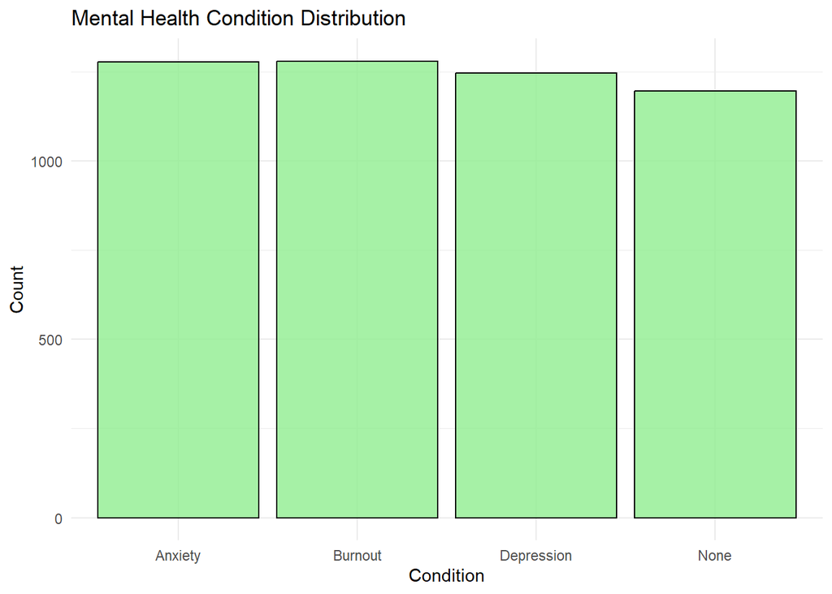

```r
ggplot(Remote, aes(x = Mental_Health_Condition)) +
  geom_bar(fill = "lightgreen", color = "black", alpha = 0.8) +
  labs(title = "Mental Health Condition Distribution", x = "Condition", y = "Count") +
  theme_minimal()
```

The age, Job Role, Industry and Mental Health Condition distribution are balanced, which is good for analyzing relationships with other variables like job satisfaction or stress levels.